# Brown Rockfish

*Sebastes auriculatus*

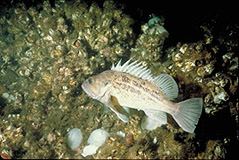

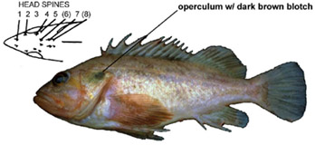

**Body color:** Light brown mottled w/ dark brown; a dark blotch on upper portion of opercle, fins dusky-pink. (Also see above underwater photo.)

**Peritoneum color:** light **Shape between eyes:** convex to flat

**Counts:** D:XIII,12-15, Ar:5-8, P1:15-19, GR:25-29, LLp:40-50, LLs:45-52, V:26-27

**Occurence:** Gulf of Alaska - Baja California

**Depth:** 128 meters **Size:** 56 cm **Species code:** 30080

**Similar species:**

- *Quillback rockfish* - body mottled yellow anteriorly w/ freckles on breast; dorsal-fin membranes deeply incised; head spine count typically differs
- *Copper rockfish* - body mottled w/ white and yellow; posterior 2/3 of lateral line clear; head spine count differs
- *Grass rockfish* - body green; gill rakers short and stubby, 17-25 (25-29, not short in Brown RF)
- *Speckled rockfish* - body w/ small dark spots; head spines weak and differ in count; maxilla extends to midorbit (to rear of orbit or beyond in Brown RF)

Back to Group

**Corrections:** If you see mistakes or want to suggest changes, please create an [issue](https://github.com/zoyafuso-NOAA/RACE_Survey_App/issues) on the source repository or

*reach out to Liz Dawson (Liz.Dawson AT noaa.gov).*